# Smaller Sooner over Larger Later options are more preferred when delay rather than amount is salient in intertemporal choice

Ben Smith, Eustace Hsu, Olivia De Santis, Xiaobei Zhang, & John R. Monterosso

We gave 226 subjects on mTurk 80 trials of an intertemporal choice task, including several preregistered manipulations and predictions (https://osf.io/tyhva/). We found significant differences in Smaller Sooner vs. Larger Later choice dependent on Amount or Delay Salience, and Hypotheticality combined with magnitude.

In the Delay Salient condition, our task varied Delay while holding Amount constant; conversely, in our Amount Salient condition, our task varied Amount while holding Delay constant. In the Hypothetical condition, in the Delay Salient Condition, subjects were always offered a hypothetical choice between $20 in 1 to 9 days, or $30 in a longer period (mean=54 days), determined by a calculated indifference point according to a hyperbolic discounting model; in the Amount Salient condition, subjects were offered a choice between a smaller amount ($1.67 to $39.39, m=$10.75) in 5 days and a larger amount ($20 to $40) in 50 or 60 days (this value was always constant within subjects). In the Real condition, contingencies were the same except amounts were actually paid out and were only 2% of the amounts offered in the hypothetical condition.

The analysis included 163 subjects, after removing 13 subjects according to preregistered criteria and an additional 50 subjects who did not show evidence of a consistent discount rate according to a post-hoc threshold.

In line with our pre-registered hypothesis, a Bayesian hierarchical logistic regression showed the odds of choosing LargerLater over SmallerSooner in the Delay Salient condition were 74% of those in the Amount Salient condition (95% CI=[68%, 81%]), controlling for covariates. The odds of selecting Larger Later vs. Smaller Sooner in either Salience Condition did not differ from 1.

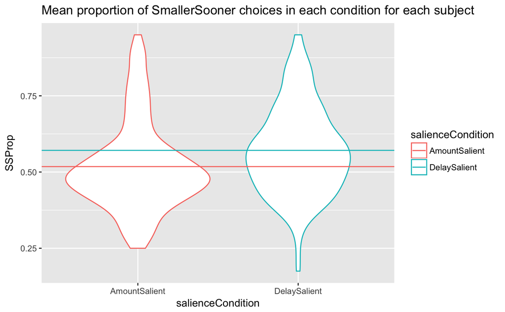

Our finding suggests that sensitivity to reward may differ based on whether delay or amount is varied from trial to trial and thus made salient. Further research should investigate the mechanisms that manipulate this sensitivity. We propose that subjects’ ability to process both Delay and Amount simultaneously may depend on their state reward responsivity, which could depend on satiation state. A study is currently under way manipulating glucose level. We predict that subjects under glucose depletion will myopically focus on either Delay or Amount, and will thus differ more in their SS to LL choice ratio across conditions compared to subjects not under sugar depletion, who will be able to focus more on Delay and Amount in both conditions.